# Capacity Comparisons: QRF and Spawner-Recruit Curves

Kevin See

April 06, 2021

<sup>1</sup> Biomark, Inc.

# 1 Introduction

We can validate Chinook summer parr estimates of capacity with spawner-recruit data from a number of watersheds. Morgan Bond at the Northwest Fisheries Science Center helped compile this data set with help from a variety of agencies and organizations including WDFW, ODFW, IDFG, USFS, BioAnalysts, Biomark, Nez Perce, etc. Most of the parr (recruits) data comes from rotary screw traps (with the exception of the Chiwawa, where snorkel surveys of parr were used to estimate parr directly). Estimates of parr-to-presmolt and parr-to-smolt survival were used to transform estimates of fall and spring emigrants to estimates of equivalent summer parr. Spawner estimates came from either redd counts or direct estimates of spawners.

From this dataset, we fit several spawner-recruit curves to each location, including Beverton-Holt, Ricker and hockey stick. The data at some locations led to some curves not fitting (no model convergence). Each of these spawner-recruit curves also generated an estimate of summer parr carrying capacity, which we can then compare to QRF estimates. We want to emphasize that the data for the spawner-recruit curves and the QRF estimates are completely independent, and therefore provide a good way to validate the QRF estimates of carrying capacity.

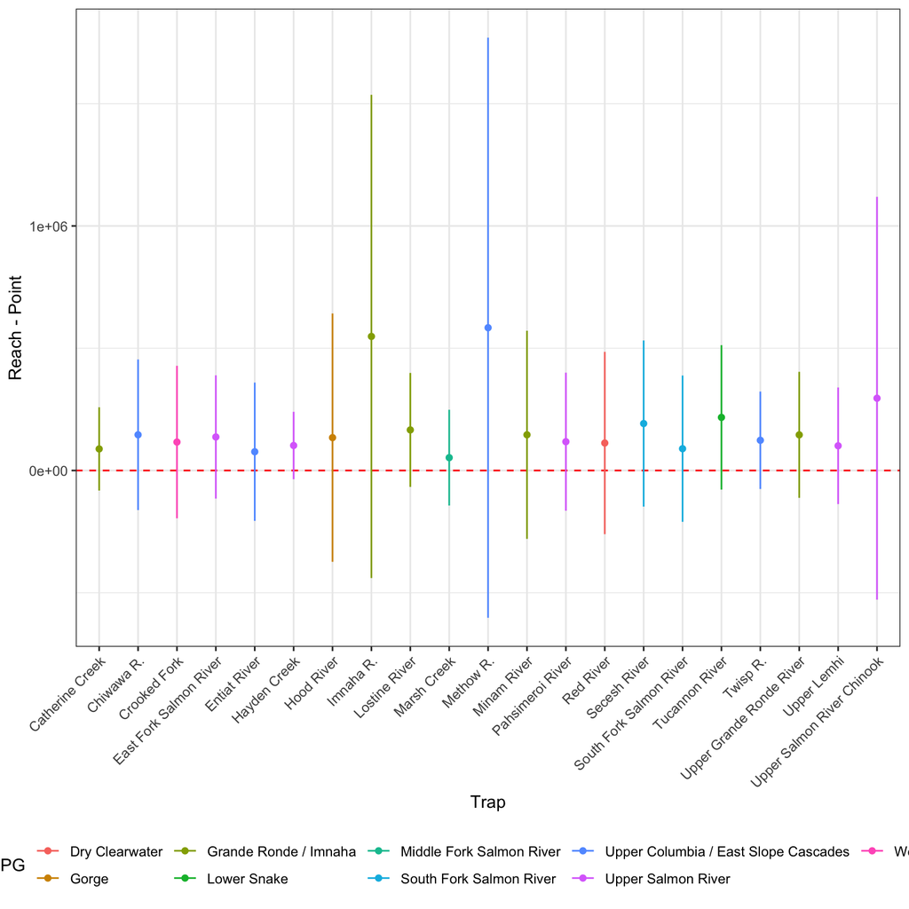

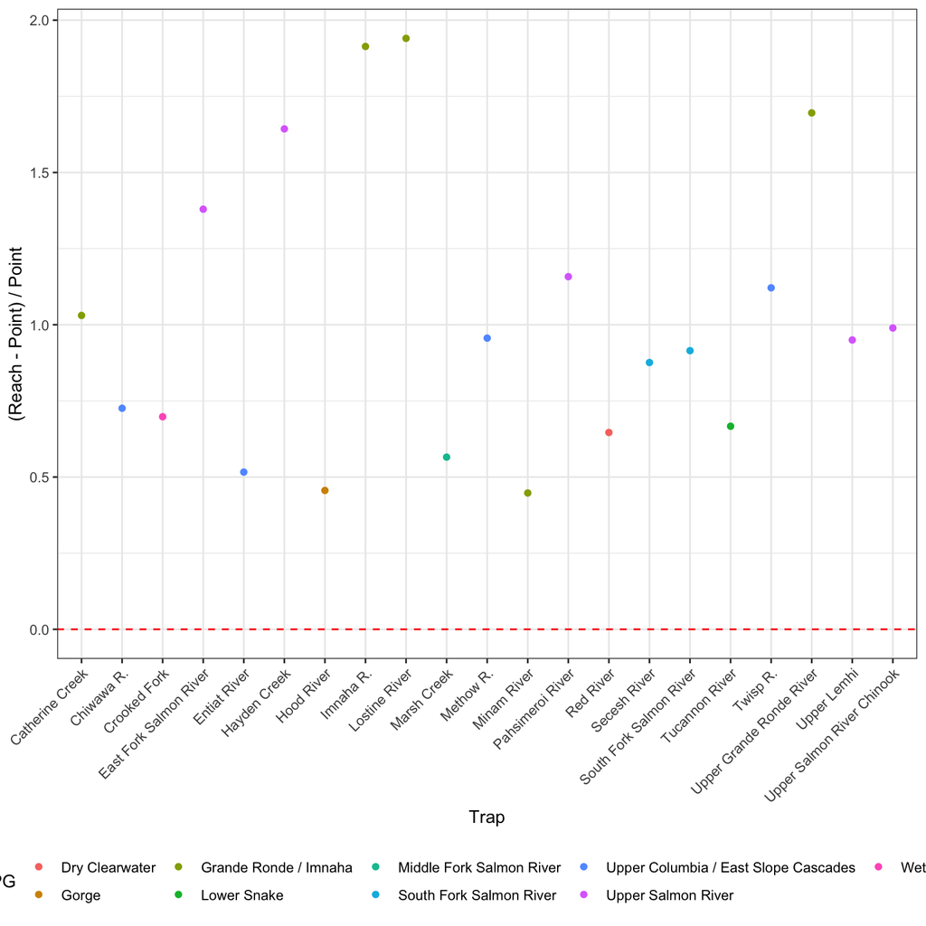

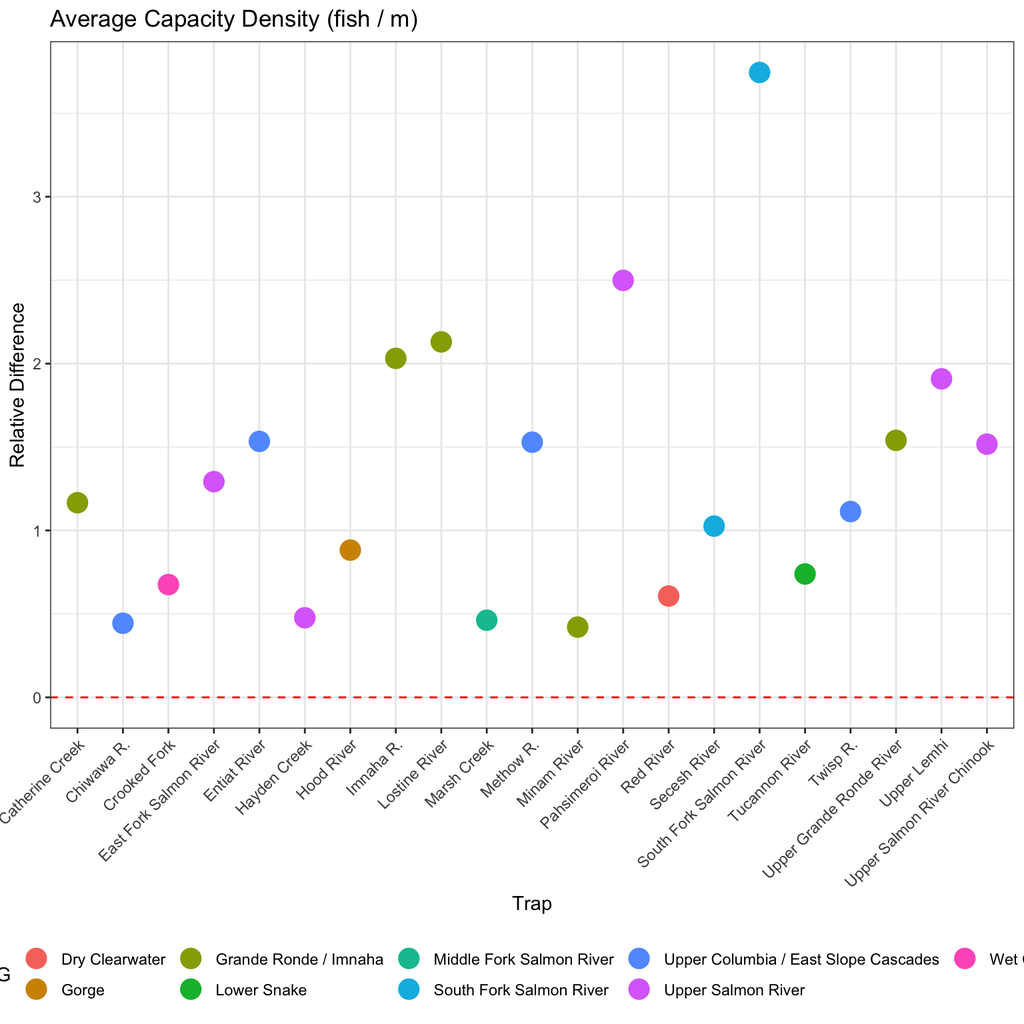

```
## Error in nls(log(Parr) ~ log(bh1(Spawners, a, b)), data = x, start = y,  :
##   Convergence failure: false convergence (8)
```

We then plotted the data, as well as the fitted curves, including the one which uses QRF estimates of capacity as one of the parameters, on the same plot, to compare the various estimates.

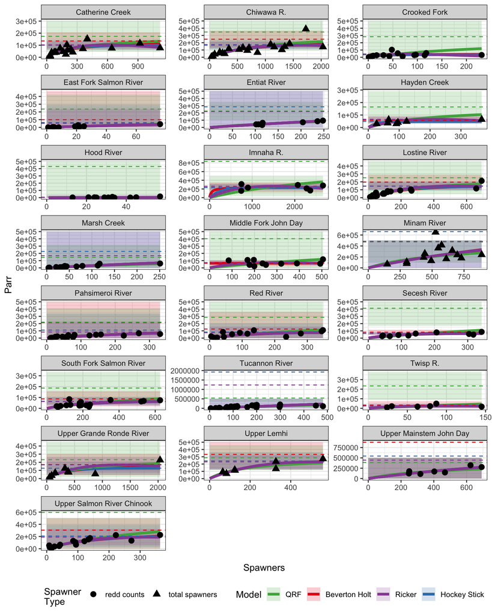

Figure 1.1: Estimates of spawners and their offspring summer parr, with various spawner-recruit curves ploted. Dashed lines are the esimates of capacity for each curve. QRF curve is a Beverton-Holt curve with the capacity parameter fixed to the QRF estimate of capacity above the screw trap.

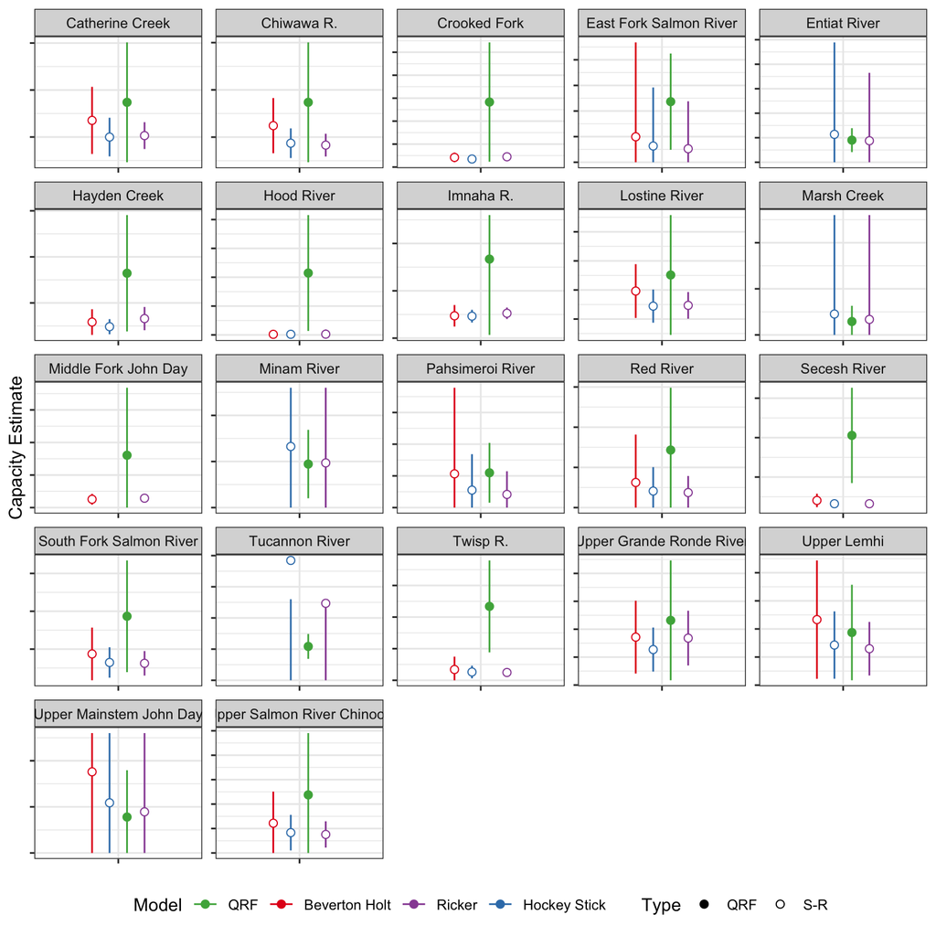